# Madrid’s air pollution analysis

Alejandro Basco Plaza, Miriam Zaragoza Pastor, Jonatan Ruedas Mora, Raúl Cruz Benita and Laura Sánchez de Rojas Huerta

20/12/2019

## Introduction and related work

Nowadays, pollution levels in Madrid is a popular topic in the news (click here for more information on the high pollution levels that Madrid’s air is facing). This has worried some of the group members who are thinking about moving to Madrid because they live in the outskirts. That is why we want to know which area of Madrid is the most suitable for us to buy an apartment.

We have found some related works that works with the same data:

[Madrid Air Quality Exhaustive Tutorial on Stationarity, Smoothing, and Seasonality](https://www.kaggle.com/nholloway/stationarity-smoothing-and-seasonality). This projects is an introduction to time series while using Madrid’s pollution datasets.

[Explore air quality in Madrid](https://www.kaggle.com/dgildas/explore-air-quality-in-madrid). It wants to explore these datasets because of the measures taken by the authorities against the use of cars in the center of Madrid.

[Madrid’s pollution weekly mean values](https://www.kaggle.com/fjortag/interactive-plot-showing-weekly-mean-values). You can see an interactive chart about the levels of pollution depending on the year that you want to see.

[Airquality analysis](https://www.kaggle.com/qgh1223/airquality-analysis). It is a project where it is plotted information about the most important pollutants of the datasets.

[Madrid’s Air Quality with ARIMA Forecasting](https://www.kaggle.com/gloriousc/madrid-s-air-quality-with-arima-forecasting). Worried about the short term and long term effects on health, the creator of this project want to analyze the air quality and predict it in for the next two years.

## Document structure and R scripts organization

This report starts with an **exploratory data analysis**, where at first, before performing any analysis, our data is described. Then we explain which features are the most relevant ones for the issues that we concern about, and at last we explain the wrangling carried out to deal with our data. After this previous step, we go through several visuals that show how our data behaves in terms of center, dispersion and distribution measures. The exploratory analysis is ended with some previous insights about the temporal evolution of our data, before starting with further analysis.

To end this work, we present some **conclussions and future work** that could be carried out to follow this research.

We provide the **scripts** used to perform the various analysis and to generate the plots. They are described below:

- **DataProcessesDataAdaptation.R**: script in which the missing value treatment is performed.
- **Final_Script.R**: script in which the data wrangling step of joining the multiple csvs in a single one is performed.
- **exploratory_analysis.R**: script used to perform the exploratory data analysis
- **TimeSeries.R**: script in which the time series analysis is performed.
- **ML.R**: script in which the machine learning approach is performed.

## Exploratory data analysis

### Dataset description

Before exposing the findings during the exploratory data analysis, important information and background about the dataset is introduced below:

The dataset used for this work was obtained from [Kaggle’s website](https://www.kaggle.com/). In this page, we can find a lot of information and datasets about the air quality in Madrid.

Our data is composed by **18 data sets** that contain observations of the level of presence of **various gases** in Madrid’s air, **which can be noxious for human health**, during the last 18 years (from 2001 to 2018). This information is recorded by 24 different stations, each one located in a different area of the city, that measure the level of presence of each pollutant through several sensors. There is data about the presence of each gas during each hour of the day, every day of every month.

The data in this data set has been collected from the original files provided by [Madrid Open Data.](https://datos.madrid.es/portal/site/egob/menuitem.c05c1f754a33a9fbe4b2e4b284f1a5a0/?vgnextoid=9e42c176313eb410VgnVCM1000000b205a0aRCRD&vgnextchannel=374512b9ace9f310VgnVCM100000171f5a0aRCRD&vgnextfmt=default) Decide soluciones organization processed them and uploaded to the [Kaggle’s website](https://www.kaggle.com/decide-soluciones/air-quality-madrid).

Regarding the **observations**, all csv files include data for every month, except the last one (2018) that only has records until May. According to this, we have the following number of rows for each data set (note that the stations.csv stores information about the 24 stations through which the information about the pollutants was measured):

| CSV | Observations |
| --- | --- |
| Stations.csv | 24 rows |
| Madrid2001.csv | 217872 rows |
| Madrid2002.csv | 217296 rows |
| Madrid2003.csv | 243984 rows |
| Madrid2004.csv | 245496 rows |
| Madrid2005.csv | 237000 rows |
| Madrid2006.csv | 230568 rows |
| Madrid2007.csv | 225120 rows |
| Madrid2008.csv | 226392 rows |
| Madrid2009.csv | 215688 rows |
| Madrid2010.csv | 209448 rows |
| Madrid2011.csv | 209928 rows |
| Madrid2012.csv | 210720 rows |
| Madrid2013.csv | 209880 rows |
| Madrid2014.csv | 210024 rows |
| Madrid2015.csv | 210096 rows |
| Madrid2016.csv | 209496 rows |
| Madrid2017.csv | 210120 rows |
| Madrid2018.csv | 69096 rows |

We can also differentiate two domains whose columns represent different data:

On the one hand, as it was mentioned above, we have the Stations.csv with six columns, which contain information about the stations:

- **id**: unique identifier for each station.
- **address**: location of the station in Madrid city.
- **Three additional columns** that stand for the exact location coordinates of the station.

On the other hand, we have the data sets named Madrid20xx.csv, which contain the observations about Madrid’s air pollution itself. Some of these csv files have 14 columns, others 16 and others 17. These columns include information about the level of presence of each pollutant in Madrid’s air, the station that measured the information, and the date (year, month, day, hour, minute and second) in which this information was obtained by the station.

We have the following number columns in the csv files:

| CSV | Features |
| --- | --- |
| Stations.csv | 6 columns |
| Madrid2001.csv | 16 columns |
| Madrid2002.csv | 16 columns |
| Madrid2003.csv | 16 columns |
| Madrid2004.csv | 17 columns |
| Madrid2005.csv | 17 columns |
| Madrid2006.csv | 17 columns |
| Madrid2007.csv | 17 columns |
| Madrid2008.csv | 17 columns |
| Madrid2009.csv | 17 columns |
| Madrid2010.csv | 17 columns |
| Madrid2011.csv | 14 columns |
| Madrid2012.csv | 14 columns |
| Madrid2013.csv | 14 columns |
| Madrid2014.csv | 14 columns |
| Madrid2015.csv | 14 columns |
| Madrid2016.csv | 14 columns |
| Madrid2017.csv | 16 columns |
| Madrid2018.csv | 16 columns |

### Data wrangling

Before getting to work with the previously described data, some steps were performed in order to make the data more manageable:

#### Selected Features

As it was mentioned before, the data sets that record information about pollution in Madrid’s air provide data about several gases that can be harmful for human health. To carry on the upcoming analysis, we are concerned about the most harmful ones: [CO](https://www.epa.gov/indoor-air-quality-iaq/carbon-monoxides-impact-indoor-air-quality), [O3](https://www.epa.gov/ground-level-ozone-pollution/health-effects-ozone-pollution), [SO2](https://www.epa.gov/so2-pollution/sulfur-dioxide-basics#what%20is%20so2), [PM10](https://www.epa.gov/pm-pollution/health-and-environmental-effects-particulate-matter-pm) and [NO2](https://www.epa.gov/no2-pollution/basic-information-about-no2).

As all the previous links recall (the reader can click on the names of the pollutants mentioned above for more information on the environmental and health effects they cause), all of these 5 pollutants can cause different types of pain in humans, such as chest pain, and can hurt vital organs, like lungs. Some of them are responsible for environmental phenomenons like acid rain, that can harm sensitive ecosystems very easily, or haze (also known as reduced visibility). Some of them also contribute to contaminate lakes and other big water resources, changing their acidity.

After these insights, it is clear that when choosing a new place to live, it is very convenient to take a look at what environmental factors can harm our health, and these five pollutants are very important ones. Therefore in our upcoming analysis we will be focusing specifically on the behavior of these pollutants.

#### Missing values treatment

As we can observe in the plot below, there is a **high amount of missing values** in the variables that we concern about:

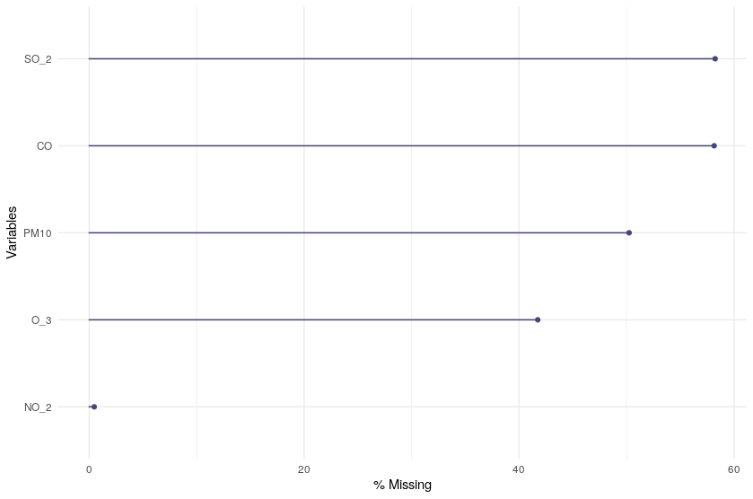

Thus, in order to deal with missing values, the **mean of each one of the variables for each year, month and station is computed**, so that all the missing values for each one of the pollutants in that same year, month and station are imputed with the corresponding mean. In case that one station has missing values all the month, they are replaced with the **mean of the column in that same year and month from all the stations**. We have developed a separate script to **regenerate all the csv files following this treatment to erase missing values**, and then employed these treated csvs to perform the rest of the analysis. The ultimate goal of this approach is **to reduce the time it takes to execute this script**: it would be very time consuming to execute it every time we need the data.

### Descriptive statistics analysis

After wrangling our data as it was necessary, we are ready to take a first look at our variables.

To start exploring our data, the distribution of the variables in our dataset in terms of **center, dispersion and distribution descriptive measures**, is analysed below.

We will end this section providing the reader some **insights on the temporal evolution of our data**, what historical patterns can be extracted and how they may relate to other real world phenomena.

#### Center, dispersion and distribution measures

The plot below is useful to visualize the center measures of the five selected variables:

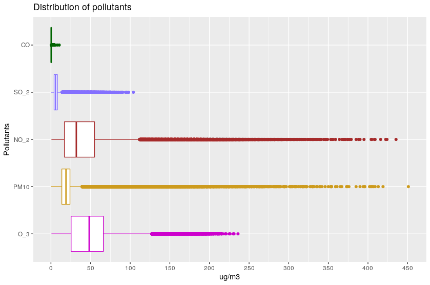

As we can see, variables NO2, O3 and PMH10 spread along wide ranges, while variables SO2 and CO spread along narrower ranges. A characteristic that they all share is that all of them have many outliers or highly unexpected values.

The histograms below show a better insight of the shape of the distribution of the variables: as we can see, all of them are highly skewed to the right, so they don’t follow a normal distribution.

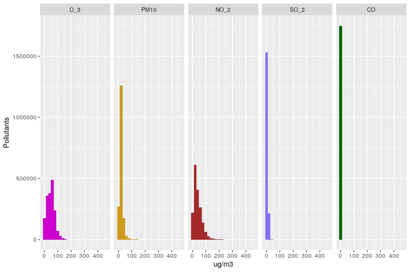

In the plot above, we can also observe a phenomenon that leads us to the conclussion that, depending on what we want to do with the data in upcoming sections, it may be a good approach to normalize it: variables SO2 and CO always take values that are very close to 0, while the other variables can reach much higher values.

### Data insights

It is interesting to answer some questions related to our data, in order to acquire some previous knowledge on how pollution behaves in Madrid’s air, taking into account factors like year month and hour in the day, before procceeding to further steps in the project.

It is important to highlight that the questions that we intend to answer in this section are merely exploratory. We are still not trying to predict any phenomenon, but it may be interesting to **find out some patterns in the temporal evolution of the five pollutants**.

At first, it is interesting for us to observe the **yearly evolution of the maximum value that each pollutant reaches each month**. In order to do so, first the maximum value for each day on each month and year is computed. Then, the average value for each month per year is obtained. Note that the values have been normalized to be on the same scale. The resulting plot, looks as follows:

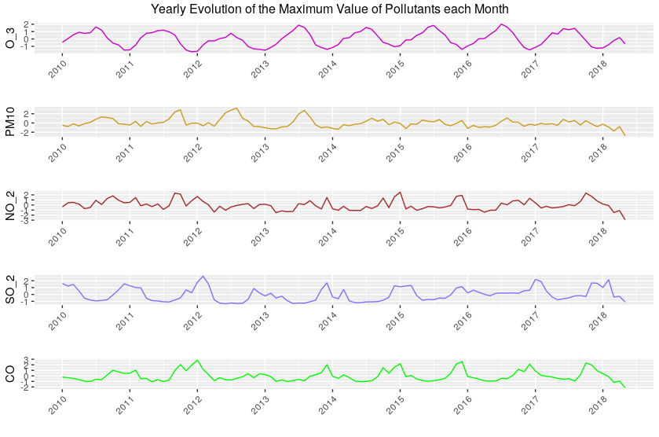

From the plot above we can see some curious information:

- the clear patterns followed by **O3** and **SO2** are the opposite: while the levels of O3 reach their yearly maximum during the months in the middle of the year (summer months) and decrease towards the end of the year, we observe the opposite trend for SO2, that reaches its yearly minimum values towards the middle of the year, and its maximum towards the end.
- **PM10** levels have reached a more regular trend since year 2014. The trend of this variable is very irregular. This also happens with variable **NO2**, which has an irregular trend aswell, but this variable seems to reach the yearly maximum value towards the end of the year, even though the maximum value can change a lot from one year to another.
- The temporal evolution of variable **CO** is more irregular than the one for SO2 and O3, but a pattern is also appreciated: the yearly maximum value is reached mostly towards the end of the current year and the beginning of the next one, in the coolest months.

To support these findings, we provide the following set of plots:

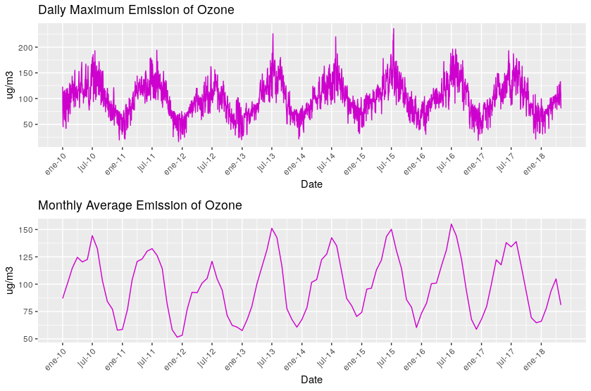

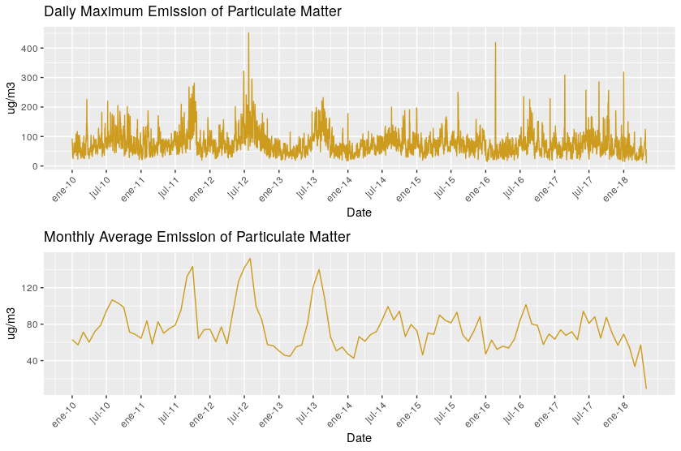

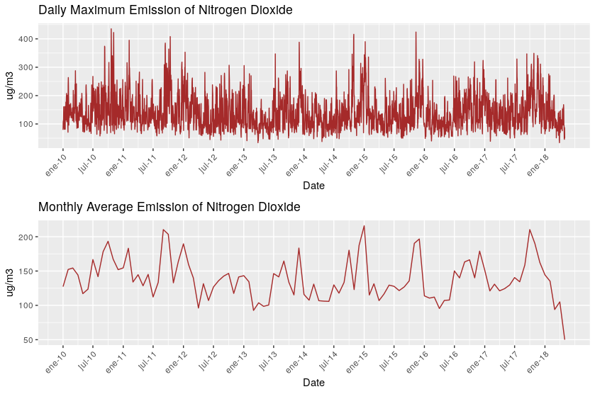

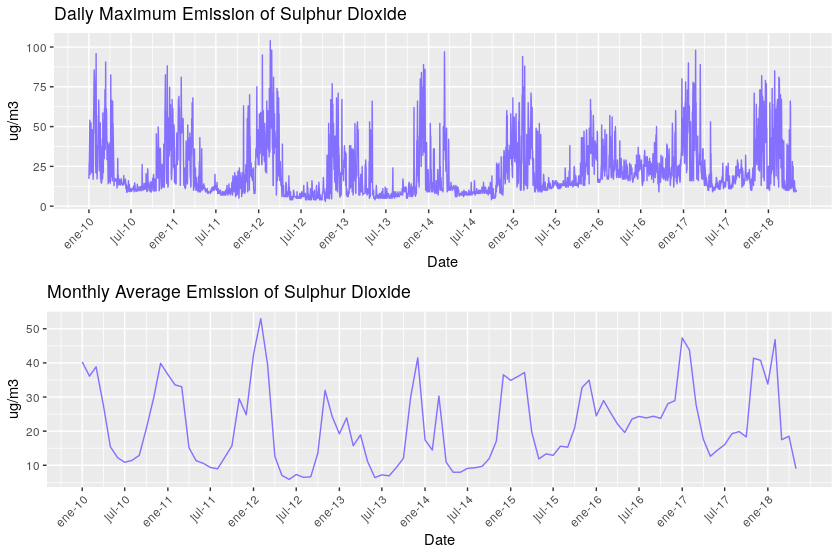

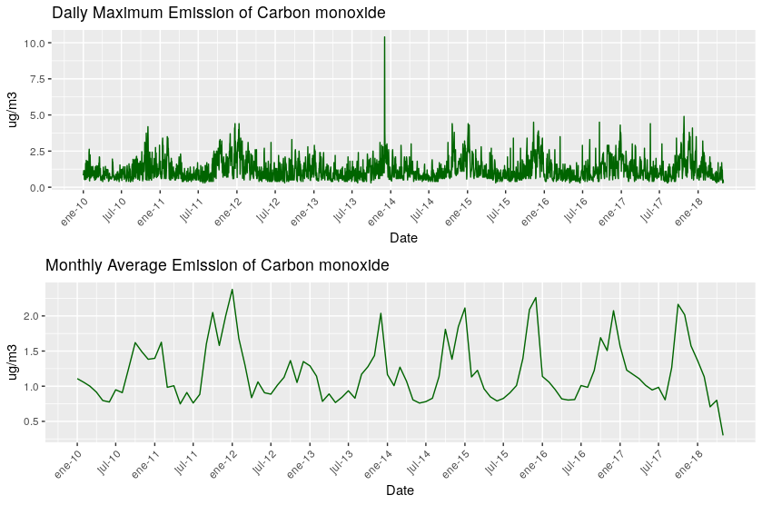

For **O3** and **SO2**, the previously observed patterns are maintained: the month of the year in which O3 reaches its maximum level is july, while the month of the year in which it reaches its lowest level is january. SO2 behaves the opposite way: winter months are more prone to have higher levels of this gas than summer months. However, we can find a common trend for both gases: the minimum level of SO2 and O3 that is present in Madrid’s air has increased since 2015, which leads to the conclussion that the general level of presence of these two gases seems to be growing.

For **PMH10**, we can see that the daily minimum level of the gas seems to be slightly decreasing, which is good news. The overall trend of the temporal evolution of the level of presence of this pollutant is still irregular, reaching its maximum values in 2011, 2012 and 2013. Since 2014, the stiffness of irregularities has decreased, but the overall trend of PMH10 seems to be stabilizing in a higher level of presence of this gas, unitl january 2018, when it dramatically decreases.

**NO2** follows a similar trend to the one previously described for PMH10: in the last years, the overall level of presence of the gas seems to be increasing, to dramatically decrease in january 2018, and the overall pattern that it follows is more irregular than the one followed by PMH10.

It also seems that the level of **CO** in Madrid’s air is slightly increasing since 2015: the trend followed by minimum values is stabilizing towards a higher value than it was before this year. CO follows a more regular pattern than PMH10 and NO2, decreasing every july and increasing towards january, but there seems to be additional factors during the rest of the year that generate some fluctuations in the pattern.

The patterns followed by the most regular pollutants (O3, SO2 and CO) can be intuitively explained by some real world events:

**O3** is rarely emitted by anthropogenic sources: it is, instead, a direct consecuence of some quimical reactions that take place [in the presence of sunlight](http://www.apis.ac.uk/overview/pollutants/overview_O3.htm), which explains why O3 levels are so high during the summer months. On the other hand, **SO2** emissions are a direct consecuence of human action: [burning fossil fuels](https://sciencing.com/major-sources-sulfur-dioxide-10011402.html). One fact that could explain the high level of SO2 during winter may be that during these months, there is a higher industrial activity than in summer. **CO** emissions are caused by [high motor-vehicle emissions](https://www.nap.edu/read/10378/chapter/3#25), so the high level of CO during winter could be explained as a consecuence of higher traffic levels in an area like Madrid during winter than during summer. Probably, if we analysed the levels of CO in a turistic place, the level of this gas would be higher in summer than in winter.

## Strength of relationships

As our intention is to make predictions using our data, it is convenient to analyse the linear relationships among the five pollutants, if any. In order to do so, the correlation matrix is represented in the plot below:

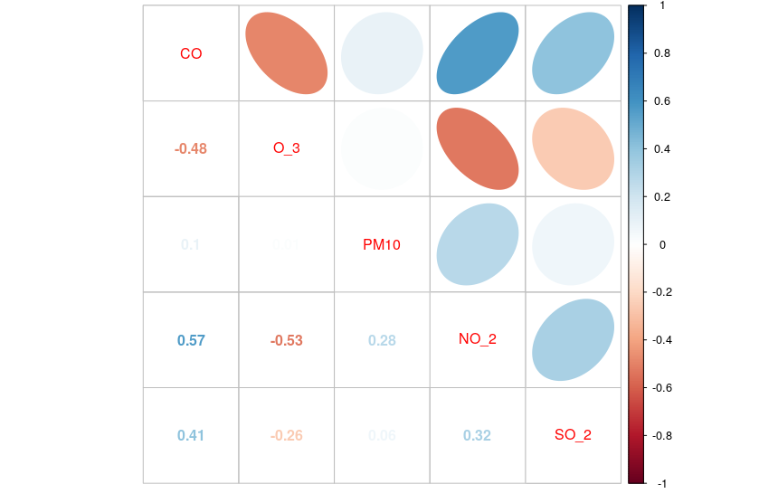

In the plot, we can observe that the most correlated pair of variables is CO and NO_2, which are positively related with a value of 0.57. They are followed by O3 and NO2, which are negatively correlated with a value of -0.53.

This result is coherent, as the variables recorded in our data seem to be the outcome of some other predictors which are not included in our dataset. For instance, a high number of manufacturing plants in the city, or high traffic levels, could be a direct cause of a high level of some of the gases that our five variables stand for, like SO2.

Due to these findings, in upcoming steps of this project we will not be trying to predict any of the five variables as an outcome of the others.

## Prediction

### Time series

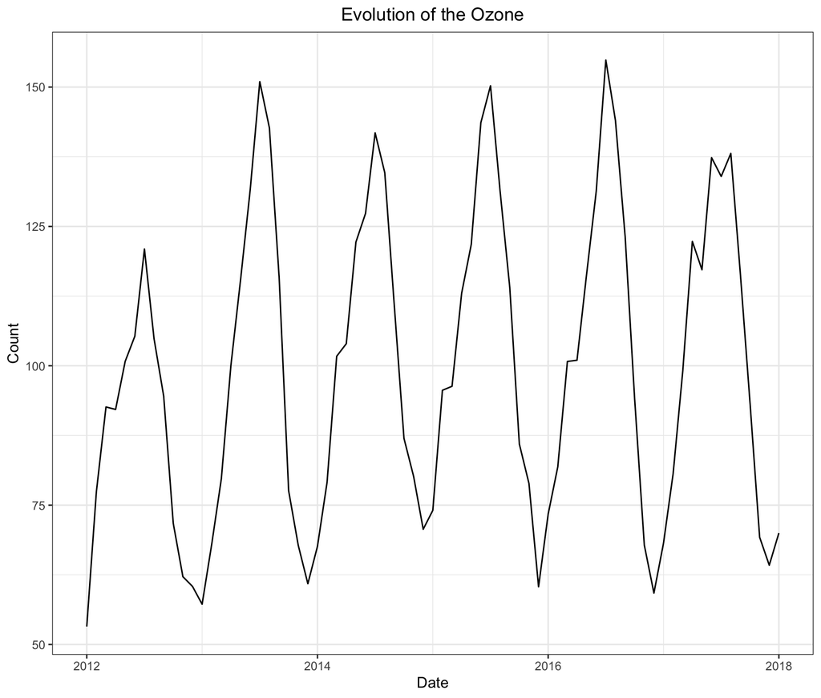

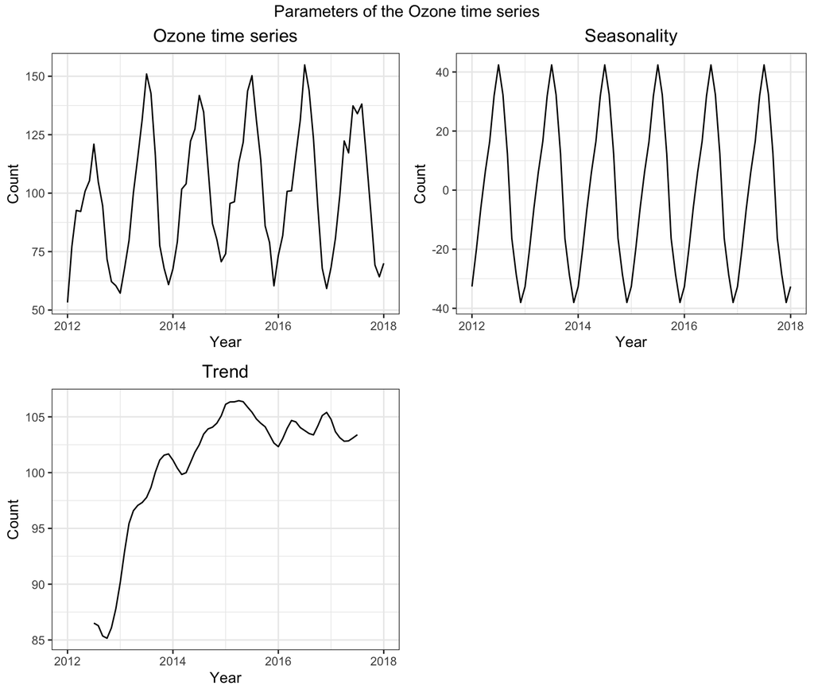

When making the ETS model we obtain the following:

ETS(M,N,M)  
Call: ets(y = train_ts)  
Smoothing parameters:  
alpha = 0.2495  
gamma = 1e-04  
Initial states:  
l = 95.8235  
s = 0.6168 0.7004 0.8541 1.1307 1.3166 1.433  
1.3101 1.1716 1.0697 0.9337 0.8102 0.6532  
sigma: 0.0766  
AIC AICc BIC  
609.0884 617.6598 643.2384

These data correspond to the ETS model that has been estimated for our data. Once this data is obtained, we make the plots to see everything graphically. The following graph shows the prediction you make based on the data we have provided. As you can see, it makes a pretty good prediction since, as you can see in the graph, the red line that represents our predictions has a shape that resembles that of the real data represented in green.

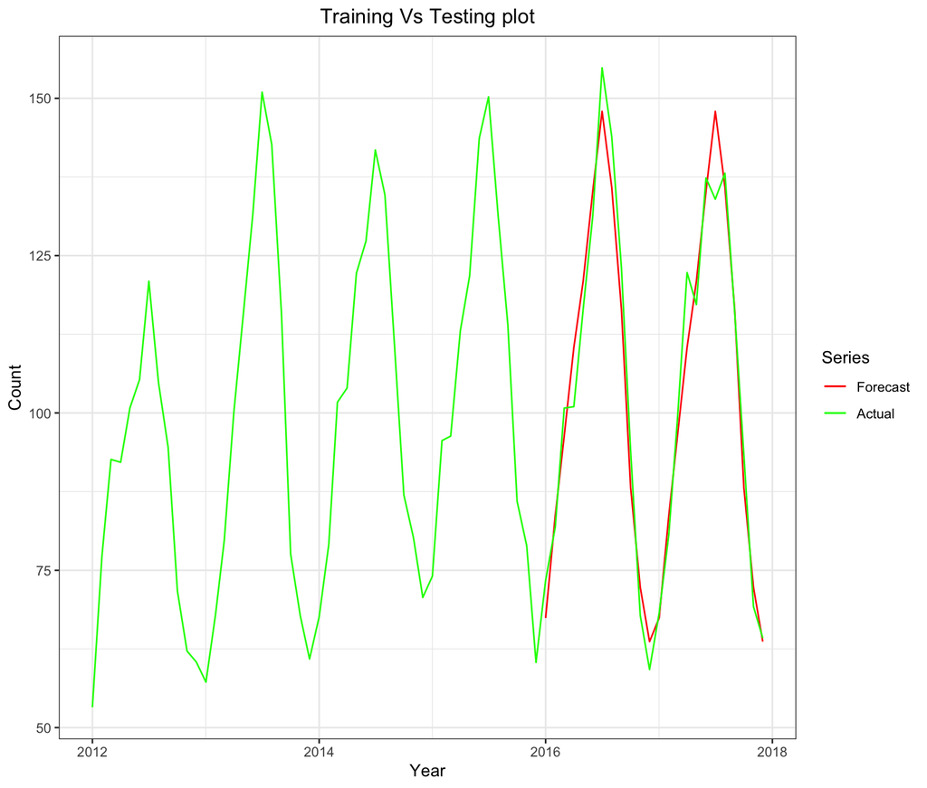

After making the prediction we have obtained the histogram of the errors produced during the prediction. The graph shows that the residues have a constant variation over time and their distribution tends to be normal, focusing on 0.

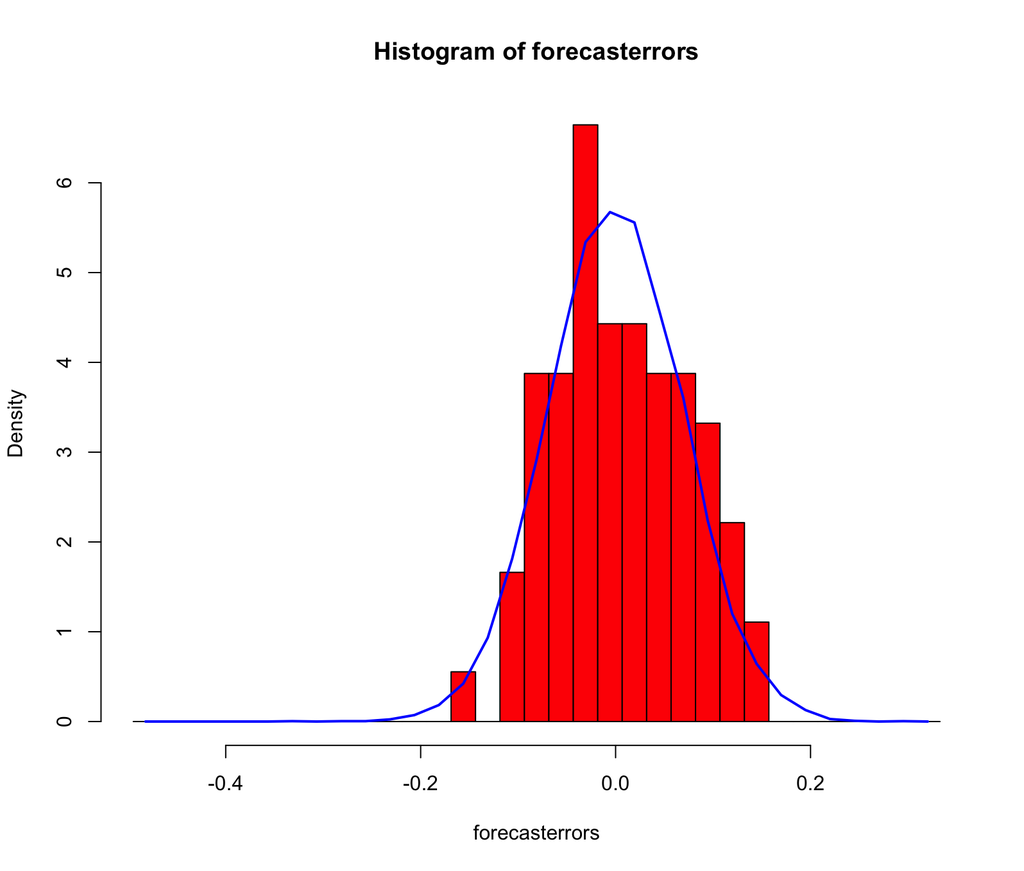

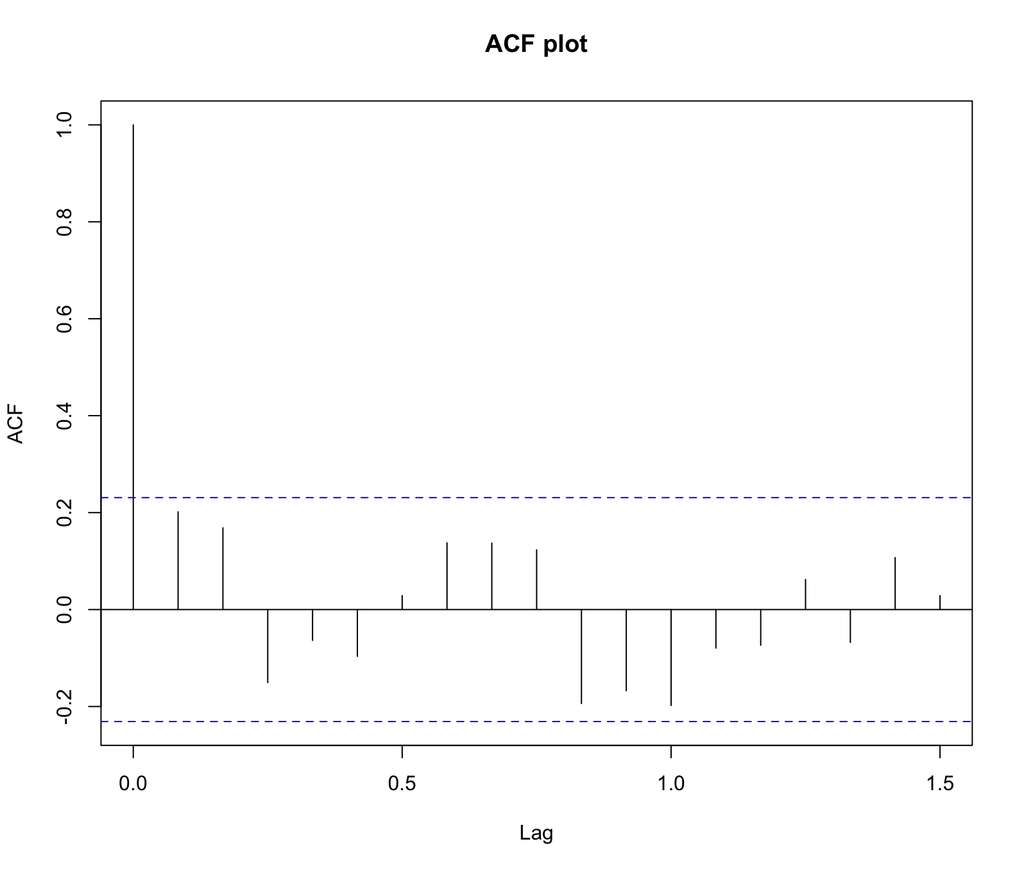

Finally, the plot of the waste was done to complete the validation of the model. To verify that the model is satisfactory, the residuals should look random. In our case, we could consider it valid since it does not follow any pattern but it has random values and grows and decreases randomly regardless of the season and the values obtained in previous years.

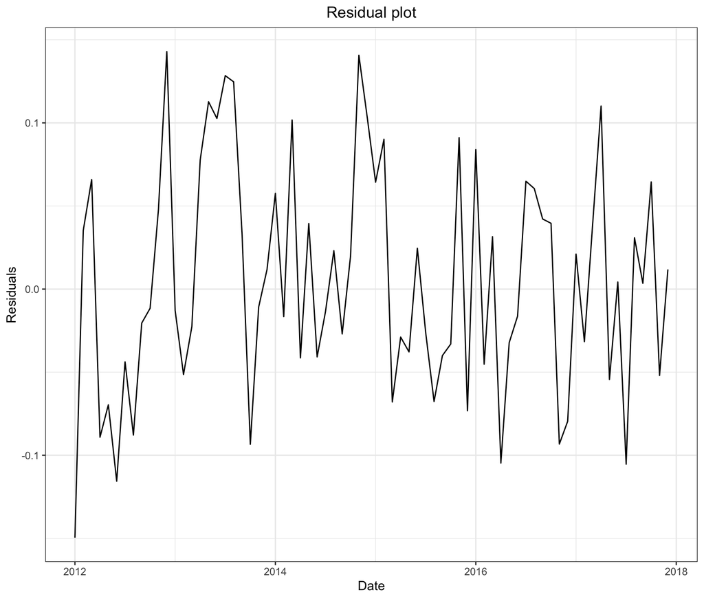

## Conclussions and future work

After the complete analysis of our data, we are able to draw some conclussions:

The exploratory data analysis gives us some accurate hints on how the five most harmful pollutants behave through time, and what patterns they follow. From the temporal evolution plots provided, we were able to see that O3, SO2 and CO are the pollutants that follow the most regular behavior: O3 increases in summer, probably due to sunlight and the quimical reactions that it promotes, while CO and SO2 increase notably during the rest of the year, most likely due to higher levels of traffic and industrial activity. The other two pollutants, PMH10 and NO2 are more irregular and its difficult to find a pattern. Regarding the most regular gases, we also saw that the overall levels of O3 and SO2 seem to be growing, as the minimum values for both gases seem to be higher than they used to be. If a person with a heart disease were to move to the city center, it would be wise to take this results into consideration

As an overall lesson, in future research on this domain using this data, it is convenient that additional variables that can work as predictors are used in the analysis, for both the machine learning and temporal series approaches. For example, the level of traffic in the city could be a good predictor to determine the growth of SO2 and CO, while the level of sunlight could be another predictor for O3. This would allow future contributors that are interested on this domain to perform a prediction based on factors other than temporal evolution or past values of a pollutant, to make the predictions more accurate.